# Efficient Market Hypothesis (Group assignment)

Author

Juan Garbayo - Time Series Analysis

```r
library(fpp3)
library(patchwork)
library(zoo)
```

# References

[1] Fama, Eugene (1970). “Efficient Capital Markets: A Review of Theory and Empirical Work”. Journal of Finance. 25 (2): 383–417. doi:10.2307/2325486. JSTOR 2325486.

[2] Investopedia - Efficient Market Hypothesis [Link](https://www.investopedia.com/terms/e/efficientmarkethypothesis.asp)

# The Efficient Market Hypothesis

The goal of this assignment is to compare a prediction strategy based on the Efficiet Market Hypothesis (EMH) with the first of the non-trivial models you will work with: exponential smoothing.

Essentially, the EMH states that stocks are accurately priced and reflect all available information. This makes it impossible to consistently beat the market by analysis.

In his influential 1970 paper ([1]), Eugene Fama proposes three categories of efficiency that differ in the information considered reflected in the prices:

1. *Weak-form of the EMH*: considers information contained in historical prices.
2. *Semi-strong form of EMH*: considers information publicly available beyond historical prices.
3. *Strong-form*: considers private (privileged) information.

Here we are going to consider the weak-form of the EMH and work only with the information contained in historical prices.

# Assignment

The assignment consists in:

### **1. Download historical data from a Stock Market Index and generate a dataset with that data.** (0.5 point)

The idea is that you **download the data using notebook 4_2**, **store it as a .csv** and **import it here.**

- **Standard & Poor’s 500 (S&P 500):** tracks the 500 companies with the largest market cap in USA.
- **Financial Times Stock Exchange:** tracks the 100 companies with the largest market capitalization on the London Stock Exchange.

The date ranges to be used are:

- **Initial date**: 7-th of May 2017
- **Final date**: the current date.

**Your final dataset must be an object of type `tsibble` with the following characteristics**:

- key = symbol
- index = trading_day

```r
#IMPORT
tr_data <- readr::read_csv("FTSE_Prices.csv")
#TRANSFORMATION AND INTERPOLATION (tr day 165)
tr_data <- tr_data %>%
              as_tsibble(key = symbol, index = 'trading_day') %>%
              mutate(close = na.approx(close))
```

### **1.1 Create a time-plot of your data and briefly describe it (max 75 words)** (0.5 points)

```
Plot variable not specified, automatically selected `.vars = close`
```

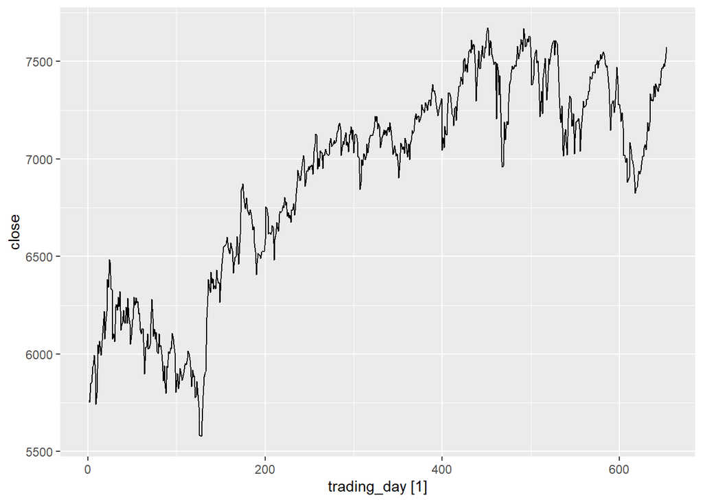

```r
autoplot(tr_data)
```

```r
The data shows a period of overall growth alternating climbs and recession in the
price.

However there are difficulties associated with judging the overall trend of aggregated
indexes such as SP500 or FTSE100. Among others:

* Complexity and diversity of constituent stocks
* Changes in constituent stocks
* Econoic cycles (for example, the data selected leaves out the COVID crisis)
* Geopolitical factors
* Market irrationality
* Lagging nature of indices (reflect what happened rather than what will happen)
```

### **2. Create three training datasets containing 80, 60 and 40% of your data** (0.5 points)

```r
#SOLUTION
n_rows <- nrow(tr_data)
train_1 <- filter(tr_data, trading_day <= ceiling(n_rows * 0.8))
train_2 <- filter(tr_data, trading_day <= ceiling(n_rows * 0.6))
train_3 <- filter(tr_data, trading_day <= ceiling(n_rows * 0.4))
```

### **3. Fit the following model specifications to your data** (0 points).

Once you have defined your training dataset, run the following code to fit the models below to your data:

- Naive model: `NAIVE(close)`
- Simple Exp. Smoothng: `ETS(close ~ error("A") + trend("N") + season("N"))`

```r
fit_tr1 <- train_1 %>%
  model(
    naive_tr1 = NAIVE(close),
    ses_tr1 =  ETS(close ~ error("A") + trend("N") + season("N"))
  )

fit_tr2 <- train_2 %>%
  model(
    naive_tr2 = NAIVE(close),
    ses_tr2 =  ETS(close ~ error("A") + trend("N") + season("N"))
  )

# Bind all the models in a single mable to handle forecasts more easily.
fit <- bind_cols(
  fit_tr1 %>% select(-symbol), # Exclude column symbol to be able to bind columns
  fit_tr2 %>% select(-symbol),
)

fit
```

```
# A mable: 1 x 4
  naive_tr1      ses_tr1 naive_tr2      ses_tr2
    <model>      <model>   <model>      <model>
1   <NAIVE> <ETS(A,N,N)>   <NAIVE> <ETS(A,N,N)>
```

The result of this step should be a `fable` or forecast table. Name it `fc`

Add a column `h` to `fc` indicating the forecast horizon of each forecast.

- After adding that column, apply the following command: `as_fable(response = "close", distribution = close)`. This is to ensure that the output after performing these operations is still a fable.

```r
fc <- fit %>% forecast(h=7)
fc
```

```
# A fable: 28 x 4 [1]
# Key:     .model [4]
   .model    trading_day          close .mean
   <chr>           <dbl>         <dist> <dbl>
 1 naive_tr1         524  N(7565, 5070) 7565.
 2 naive_tr1         525 N(7565, 10141) 7565.
 3 naive_tr1         526 N(7565, 15211) 7565.
 4 naive_tr1         527 N(7565, 20282) 7565.
 5 naive_tr1         528 N(7565, 25352) 7565.
 6 naive_tr1         529 N(7565, 30423) 7565.
 7 naive_tr1         530 N(7565, 35493) 7565.
 8 ses_tr1           524  N(7561, 5038) 7561.
 9 ses_tr1           525  N(7561, 9155) 7561.
10 ses_tr1           526 N(7561, 13273) 7561.
# … with 18 more rows
```

```r
fc <- fc %>%
  group_by(.model) %>%
  mutate(h = row_number()) %>%
  ungroup() %>%
  as_fable(response = "close", distribution = close)
```

### **5. For each combination of model, training dataset and forecast horizon compute the RMSE and MAE. Store the result in a variable called `summary`** (1 point)

```r
#SOLUTION
summary <- accuracy(fc, tr_data, by = c("h", ".model")) %>% select(-c(MPE, MASE, RMSSE, ACF1, ME))
summary
```

```
# A tibble: 28 × 6
       h .model    .type  RMSE   MAE  MAPE
   <int> <chr>     <chr> <dbl> <dbl> <dbl>
 1     1 naive_tr1 Test   20.6  20.6 0.272
 2     1 naive_tr2 Test   35.8  35.8 0.491
 3     1 ses_tr1   Test   25.0  25.0 0.329
 4     1 ses_tr2   Test   37.7  37.7 0.518
 5     2 naive_tr1 Test   35.2  35.2 0.463
 6     2 naive_tr2 Test   71    71   0.979
 7     2 ses_tr1   Test   39.6  39.6 0.521
 8     2 ses_tr2   Test   72.9  72.9 1.01
 9     3 naive_tr1 Test   42.8  42.8 0.563
10     3 naive_tr2 Test  103.  103.  1.43
# … with 18 more rows
```

### **6. Use facet wrap to produce 3 graphs, one for each of the three error metrics used** (2 points)

The graphs should depict the RMSE for each forecast horizon and for each combination of model and training dataset.

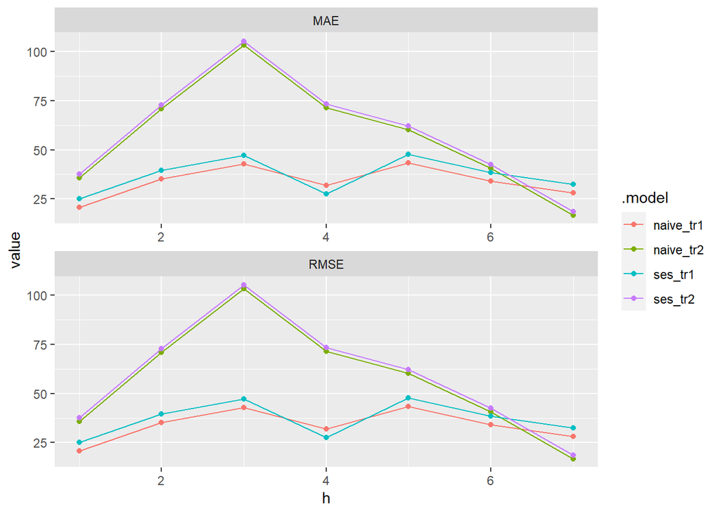

```r
#SOLUTION
summary %>%
  pivot_longer(c(MAE, RMSE), names_to = "metric", values_to = "value") %>%
  ggplot(aes(x = h, y = value, color = .model)) +
  geom_point() +
  geom_line() +
  facet_wrap(~ metric, nrow = 2 , scales = "free")
```

- Does the training dataset have an effect on the errors?

MAX 100 words

```r
From the graphs above we can observe that:

* For a given train-test split the SES and naive model have a very
close performance.
* When the train-test split is changed, the performance of both models
experiences a drastic change.
```

- Does one of the models outperform the other?

MAX 100 words

```r
It may therefore be concluded that for the two models at hand and this
particular data, the particular split performed on the data has a greater
effect than the model chosen.
```

### **7. Evaluate the same metrics on the same models, but this time using cross validation** (2 points)

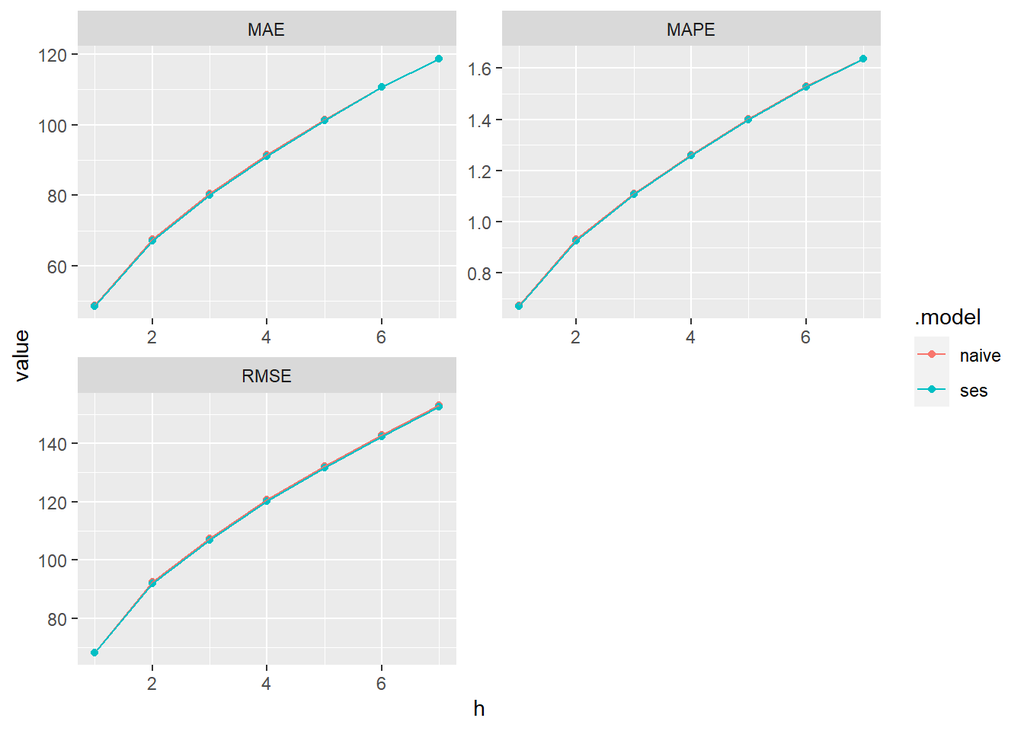

```r
# SOLUTION
tr_data_cv <- tr_data %>%
  stretch_tsibble(.init= trunc(0.4*nrow(tr_data)), .step = 1)

fit_cv <- tr_data_cv %>%
  model(
    naive = NAIVE(close),
    ses =  ETS(close ~ error("A") + trend("N") + season("N"))
  )

fc_cv <- fit_cv %>%
  forecast(h = 7) %>%
  group_by(.id, .model) %>%
  mutate(h = row_number()) %>%
  ungroup() %>%
  as_fable(response = "close", distribution = close)

summary_cv <- fc_cv %>%
  accuracy(tr_data, by=c("h", ".model")) %>% select(-c(MPE, MASE, RMSSE, ACF1, ME))
summary_cv %>%
  pivot_longer(c(MAE, RMSE, MAPE), names_to = "metric", values_to = "value") %>%
  ggplot(aes(x = h, y = value, color = .model)) +
  geom_point() +
  geom_line() +
  facet_wrap(~ metric, nrow = 2 , scales = "free")
```

- What is the difference between these graphs and the ones we generated before? Answer briefly below.

```r
The main difference is that the graph below have been computed averaging over many
training datasets, making their results statistically more representative of what
would happen on average if we used these model to forecast this data

The previous graph corresponded to a single train test split, which is why the
results are more dependent on the particular train test split than on the model.
```

- Does one of the models outperform the other?

```r
The cross-validated results show that both models behave, on average over all
training datasets, virtually in the same manner. To understand why, we may check
the distribution of the values of alpha of the SES model for the different
training datasets.
```

```r
SES_alpha_cv <-
  fit_cv %>%
  select(-naive) %>%
  tidy() %>% # Extract model parameters
  filter(term=="alpha")
```

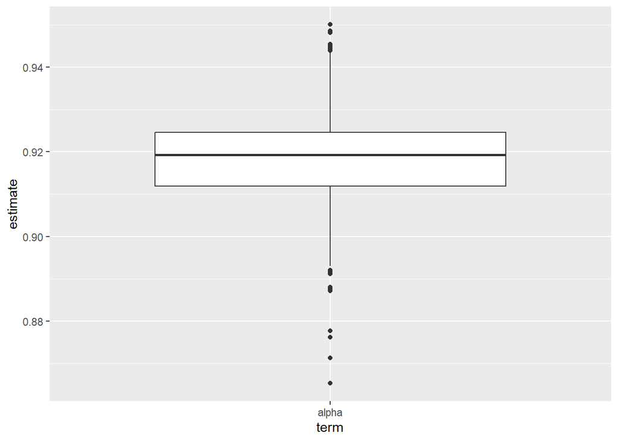

```r
SES_alpha_cv %>%
  ggplot(aes(x=term, y=estimate)) +
  geom_boxplot()
```

```r
We can see that the distribution of values of alpha for the different training
datasets is limited to the high end, with the smallest value being greater than
0.85

Recall that for alpha = 1, the SES method becomes the Naive method, while for
smaller values of alpha observations further away in the past gain weight.

Using the formula for the coefficients of alpha, we may compute the distribution
of weights for the smallest version of alpha of the different training datasets
```

```r
alpha_min <- min(SES_alpha_cv$estimate)
weights <-  vector("numeric")

# Values of the first three weights
for (i in seq(1,3)){
  weights[[i]] = alpha_min*((1-alpha_min)^(i-1))
}

weights
```

```
[1] 0.86528717 0.11656529 0.01570284
```

```r
sum(weights)
```

```
[1] 0.9975553
```

```r
The first three weights concentrate almost 100 of the distribution,
even for the smallest value of alpha.

And the most recent observation has a weight of 0.87

This shows that the method is very similar to the naive method.
```

### **8. Present your conclusions** (1.5 points)

The strategy based on the NAIVE model follows the weak form of the EMH, that is, it considers that the current prices reflect all available information. The NAIVE model has 0 parameters, it is the simplest method we can fit and serves as a benchmark.

The SES method on the other hand has 1 parameter and requires an iterative process to be fitted, in which the sum of squared residuals is minimized. It has only one parameter, but determining this parameter involves a process that is already substantially more complex than the NAIVE prediction.

However, the cross-validated accuracy metrics show that this increased complexity does not seem to provide any substantial improvement.

Regarding the accuracy metrics, the RMSE and MAE signal an error of up to 150 dollars for the forecast horizon consider. In realtive terms, this error is around 1.6 percent. as singaled by the MAPE. Is our model sufficiently good? Well **the answer it that it depends on the purpose of the model**.

- If the goal of the model is to do trading, of course the model is not sufficiently good. It also does not include any information beyond the price.
- If the goal of the model is to build an impression about the level of the market for a forecast horizon of 7 with an uncertainty quantified by the corresponding prediction intervals, the model allows us to understand the uncertainty associated with the NAIVE and SES forecast and what level of change we may see with a forecast horizon of 7 days.